# MA331-Report: 2213380

TED Talks by Speaker Sugata Mitra and Speaker mariano sigman

Ramadoss, Kirthik

## Introduction

In order to extract insights and trends from massive amounts of unstructured text—text that does not follow a predetermined format—text analytics uses a variety of machine learning, statistical, and linguistic techniques. It makes it possible for organizations, governments, academics, and the media to use the vast material at their command to make important choices. Sentiment analysis, subject modeling, named entity identification, word frequency, and event extraction are just a few of the methods used in text analytics.Sugata Mitra, a scholar in education, is the recipient of the 2013 TED Prize. His desire was to create a school in the cloud where kids could learn from one another and investigate and in 2016 Neuroscientist Mariano Sigman shares his life’s work investigating the interior workings of the human brain in his intriguing, mind-bending novel “The Secret Life of the Mind.”

## Methods

The methods are as follow: * tidying and tokenaisation , tidying is nothing but A common method of linking a dataset’s organisation is provided by tidy dataset and tokenaisation means the breaking of the words into specified manner. *Stopwords removal, that means removing of all stopwords like i, and , if from the data.* Next identification of stopwords of speaker words seperatly, that means identifing speakers stopwords *next step is visualization of stopwords. The visual representation of data in the shape of a graph, chart, bar graph, or any other style is known as data visualisation and is an essential component of data analysis.* In the next step I just visualised for speakers separetly. *And then comparing the speakers words by data visualization.

## Results

The result I have got for this data is by using the above methods.I just gathered the information about speakers “Sugata Mitra” and “Mariano Sigman” from the website tidy_talks and I rephared it here.

### best phrases displayed visually

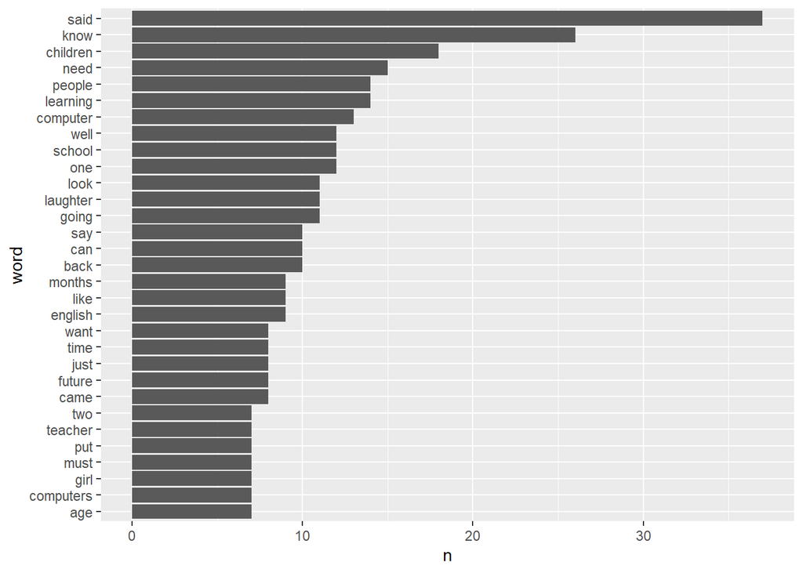

### plotting the speaker words

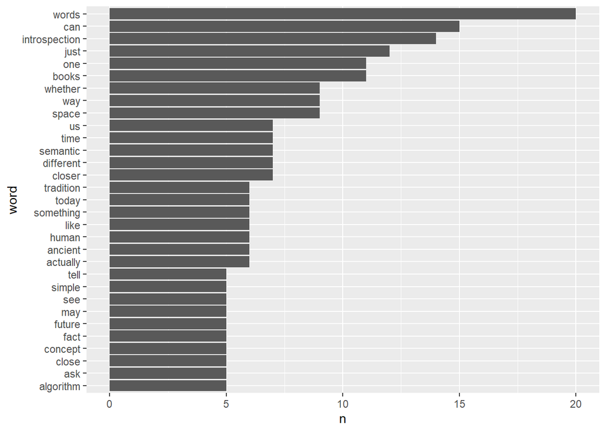

### Common words plotting between two speakers

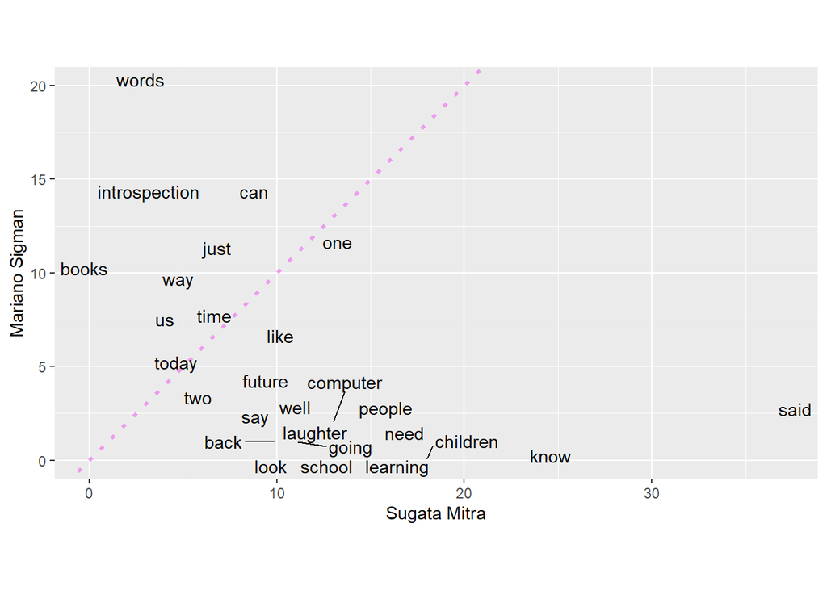

### Positive and negative words split

```
# A tibble: 774 × 6
   talk_id headline                    speaker        views word     sentiment
     <dbl> <chr>                       <chr>          <dbl> <chr>    <chr>
 1    1678 Build a School in the Cloud Sugata Mitra 3041768 learning positive
 2    1678 Build a School in the Cloud Sugata Mitra 3041768 plan     anticipati…
 3    1678 Build a School in the Cloud Sugata Mitra 3041768 plan     anticipati…
 4    1678 Build a School in the Cloud Sugata Mitra 3041768 kind     joy
 5    1678 Build a School in the Cloud Sugata Mitra 3041768 kind     positive
 6    1678 Build a School in the Cloud Sugata Mitra 3041768 kind     trust
 7    1678 Build a School in the Cloud Sugata Mitra 3041768 kind     joy
 8    1678 Build a School in the Cloud Sugata Mitra 3041768 kind     positive
 9    1678 Build a School in the Cloud Sugata Mitra 3041768 kind     trust
10    1678 Build a School in the Cloud Sugata Mitra 3041768 learning positive
# ℹ 764 more rows
```

```
# A tibble: 10 × 3
   sentiment    `Mariano Sigman` `Sugata Mitra`
   <chr>                   <int>          <int>
 1 anger                      25             18
 2 anticipation               47             56
 3 disgust                     5             11
 4 fear                       14             15
 5 joy                        11             47
 6 negative                   49             30
 7 positive                   82            143
 8 sadness                    11             14
 9 surprise                   14             44
10 trust                      48             90
```

### sentimental analysis plotting

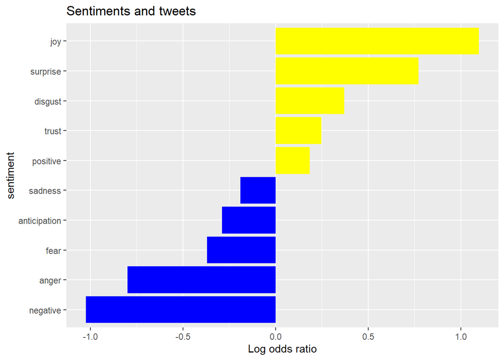